# Integrated step selection function analysis

Marie Gilbertson

2025-02-14

# Introduction

In this report, I’ll demonstrate the approach we used to fit integrated step selection functions (iSSFs). This will include calculating rolling occurrence distributions for neighboring individuals, and using these as time-varying habitat covariates.

In the manuscript for this work, we fit thousands of iSSFs across several “model types.” This is too computationally intensive for an RMarkdown report, so I will just demonstrate rolling occurrence distributions and iSSF fitting for a single indivual. This approach is readily scaled up through looping and/or parallelization.

I will also demonstrate calculating log-relative selection strength (log-RSS) values for fitting meta-analysis models, where log-RSS is the response variable. Again, we fit many models across various model types and iSSF predictors, so I will just demonstrate on a small scale. Scaling up is readily accomplished through looping and/or parallelization.

Note: I am not including the movement data preparation that occurs prior to simulating random steps and extracting covariates. This is well described in the documentation for the *amt* package, and our code for this is not novel.

For this report, we’ll start by loading the packages we’ll need. I also always set my seed as standard practice (this makes randomization reproducible).

```r
##### Clear Environment #####
remove(list=ls())


#### set seed ####
set.seed(9846)


#### load libraries ####
library(plyr)
library(dplyr)
library(adehabitatLT)
library(amt)
library(raster)
library(ggplot2)
library(tidyverse)
library(lubridate)
library(pbapply)
library(sf)
library(lmerTest)
library(lme4)
library(terra)
```

## Rolling occurrence distributions

Our methods here were based on [Schlägel et al 2019](https://doi.org/10.1111/2041-210X.13235), *Methods in Ecology and Evolution*.

For each focal individual, we calculated rolling occurrence distributions (ODs) for their neighboring conspecifics. Each set of rolling ODs could then be included as an independent, time-varying covariate in iSSFs.

The *amt* package includes a function for calculating rolling ODs, rolling_od(). This function calculates an occurrence distribution from a “slice” of movement data, using a consistent number of locations for each slice. For our study, however, we wanted to use a consistent period of time for each “slice” to account for the potential for missing data or changes in the frequency of locations.

We therefore made modifications to the rolling_od() function, creating our own rolling_od_tw() function for calculating rolling ODs based on temporal windows for each slice, rather than the number of points. Interested users should review the help file for the original rolling_od() function for further info about arguments.

```r
rolling_od_tw <- function(
    x, trast, model = fit_ctmm(x, "bm"), res.space = 1, res.time = 10,
    n.hrs = 160, show.progress = TRUE) {

  ## Basic setup steps
  res <- list()
  last <- max(x$t_)
  last.slice <- last-(n.hrs*60*60)
  diffs <- difftime(last.slice, x$t_, units = "hours")

  if (show.progress){
    pb <- utils::txtProgressBar(style = 3, max = max(which(diffs>=0)), min = 1)
  }

  if(class(x)[1]!="track_xyt"){stop("Data must by of class 'track_xyt'")}

  start.time <- x$t_[1]
  end.time <- start.time + (n.hrs*60*60)
  slice.times <- .POSIXct(character(length = max(which(diffs>=0))))
  coverage <- data.frame(matrix(nrow = max(which(diffs>=0)), ncol = 3))
  colnames(coverage) <- c("first", "last", "n.pts")

  ## loop through the time series of the data until you get to the end
  j <- 1
  repeat{
    if (show.progress) utils::setTxtProgressBar(pb, j)
    temp <- x[x$t_>=start.time & x$t_<=end.time,]
    temp$nxt.time <- NA
    temp$tdiff <- NA

    # only estimate OD for this slice if there are at least 4 points
    if(nrow(temp)>=4){
      ## remove locations so that all locations have at least 15 minutes between them
      # do iteratively to minimize data loss
      temp.new <- temp[1,]
      for(k in 2:nrow(temp)){
        # print(k)
        td <- rbind(temp.new, temp[k,])
        td$nxt.time <- c(NA, paste(td$t_[1:(nrow(td)-1)]))
        td$tdiff <- difftime(td$t_, as.POSIXct(td$nxt.time, tz = "America/Chicago"), units = "mins")

        if(td$tdiff[nrow(td)]<15){
          temp.new <- td[-(nrow(td)),]
        }else{
          temp.new <- td
        }
      }
      temp <- subset(temp.new, select = -c(nxt.time, tdiff))

      if(nrow(temp)>=4){
        suppressWarnings(res[[j]] <- od(temp, trast = trast, model = model,
                                      res.space = res.space, res.time = res.time))
        # store metadata that only applies when an OD can be fit
        coverage$first[j] <- paste(head(temp$t_,1))
        coverage$last[j] <- paste(tail(temp$t_,1))

      }else{
        res[[j]] <- NA
        coverage$first[j] <- coverage$last[j] <- NA

      }

    }else{
      res[[j]] <- NA
      coverage$first[j] <- coverage$last[j] <- NA
    }

    # store additional metadata
    slice.times[j] <- end.time
    coverage$n.pts[j] <- nrow(temp)

    # update for next iteration
    j <- j+1
    start.time <- x$t_[j]
    end.time <- start.time + (n.hrs*60*60)
    # if new end time is beyond the range of data, break loop
    if(end.time > max(x$t_)) break
  }

  ## assign the corresponding time stamps to each slice and return the final output
  res2 <- res[which(!is.na(coverage$first))]
  res <- rast(res2)
  terra::time(res) <- slice.times[which(!is.na(coverage$first))]
  attr(time(res), "tzone") <- "America/Chicago" ## make sure time zone is correct
  out <- list(res, coverage)
  names(out) <- c("res", "coverage")
  return(out)
}
```

I’ll now demonstrate using this function with movement data from one deer over a three month period. Let’s first load some data and check out the data structure.

```r
od.dat <- get(load("../Project_data/od_roll_demo_data.Rdata"))
head(od.dat)
```

```
##     id        x        y                date
## 1 5000 506838.8 296174.1 2017-02-18 06:00:54
## 2 5000 506843.8 296195.2 2017-02-18 10:00:48
## 3 5000 506849.8 296198.7 2017-02-18 14:00:22
## 4 5000 506695.9 295668.2 2017-02-18 18:00:50
## 5 5000 506858.8 294682.0 2017-02-18 22:00:28
## 6 5000 506951.8 294770.9 2017-02-19 02:00:29
```

Let’s extract just three months of data over which to calculate our rolling ODs.

```r
od.dat <- od.dat[od.dat$date>="2017-03-01" & od.dat$date<"2017-06-01",]
range(od.dat$date)
```

```
## [1] "2017-03-01 02:00:22 CST" "2017-05-31 21:01:54 CDT"
```

```r
nrow(od.dat)
```

```
## [1] 692
```

Now we’ll go ahead and use our custom rolling OD function to calculate the ODs. We’ll use “slices” of movement data that are 24 hours in duration.

```r
## We can set arguments externally when scaling up to evaluate an array of different slice durations
slice.hrs <- 24

# convert to track object
dat1 <- od.dat %>% make_track(x, y , date, id = id, crs = 3071) # make sure to use the appropriate coordinate reference system (CRS)

# make a template raster with a sizeable buffer
box <- data.frame(st_coordinates(amt::bbox(dat1, buffer = 3000))) # bounding box with 3km buffer

trast <- rast(xmin = min(box$X), xmax = max(box$X),
              ymin = min(box$Y), ymax = max(box$Y),
              res = 30, crs = "epsg:3071") # 30 meter resolution and make sure to set CRS
trast[] <- 1 # set values to 1


od_roll_tw <- rolling_od_tw(dat1, trast, model = fit_ctmm(dat1, "bm"), n.hrs = slice.hrs, res.space = 1, show.progress = F)
writeRaster(od_roll_tw$res, filename = "../Project_data/od_roll_demo_roll.tif", overwrite = T)
```

We can use the animate() function to check out how the rolling OD looks over time. This doesn’t work very well in an RMarkdown report, so we’ll just show a handful of the resulting OD rasters over time. The values (and colors) of the plotted rasters represent the probability an indivual occurred in that location during the given time slice.

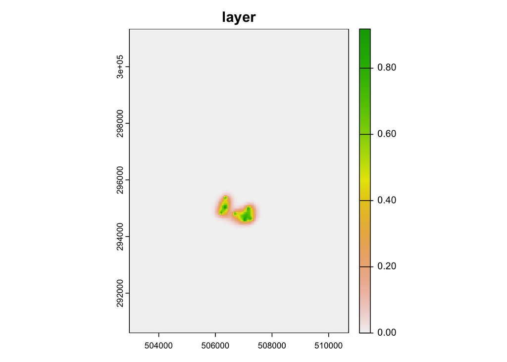

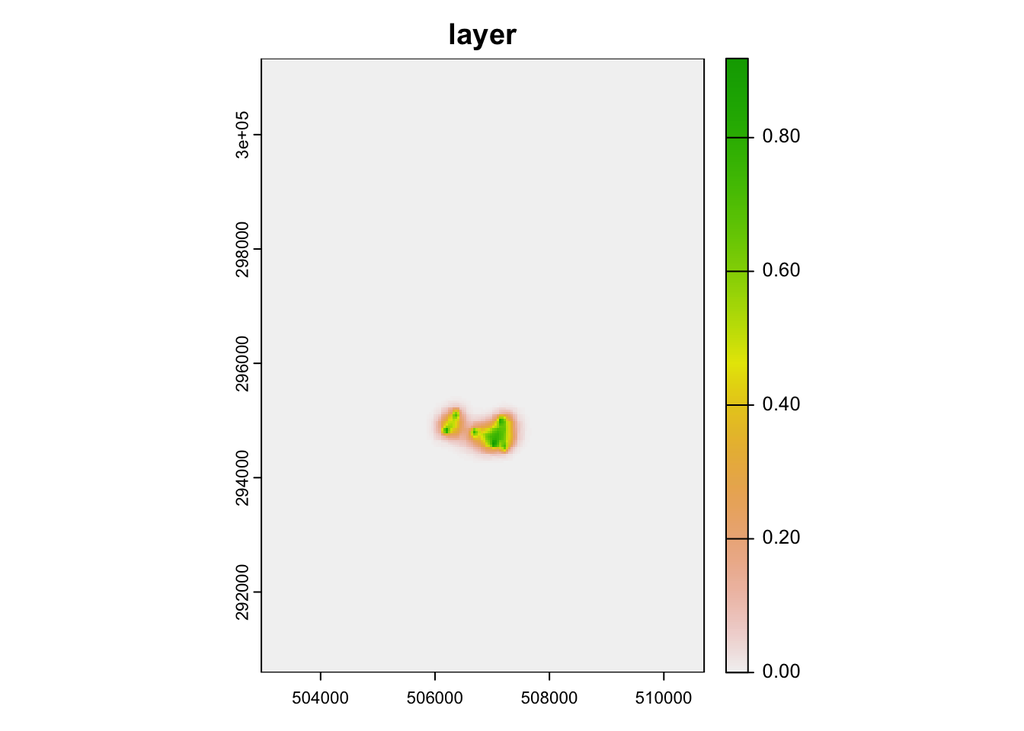

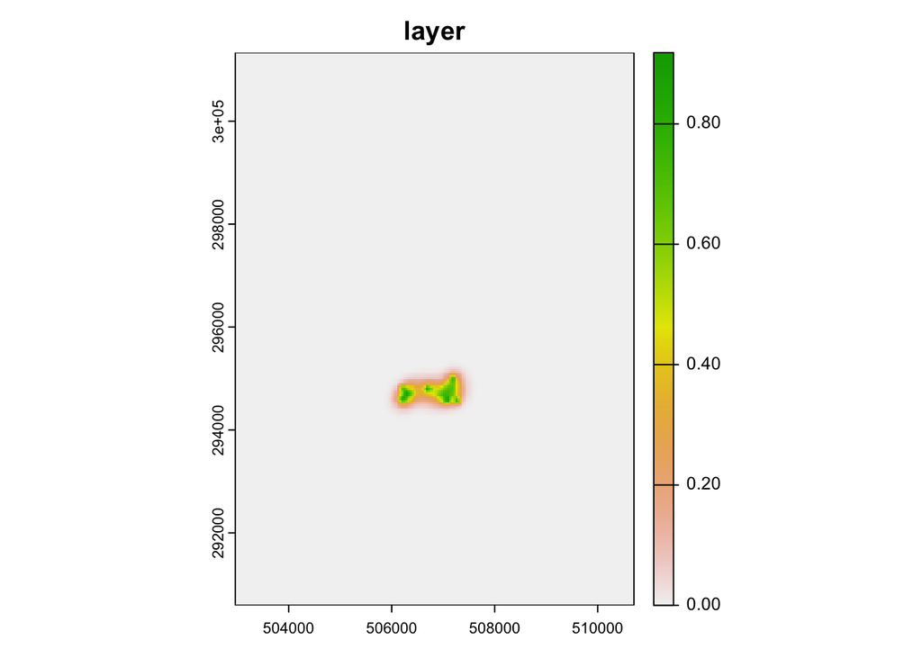

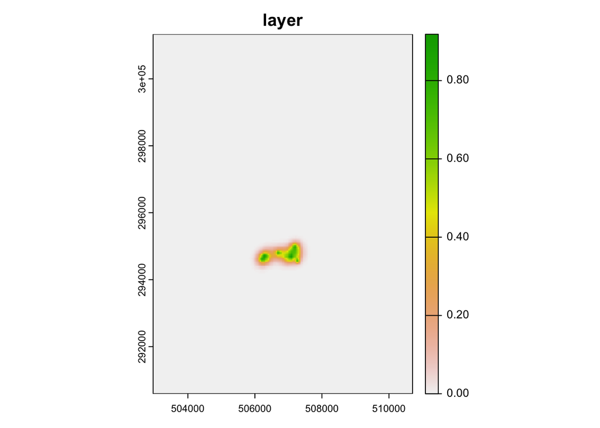

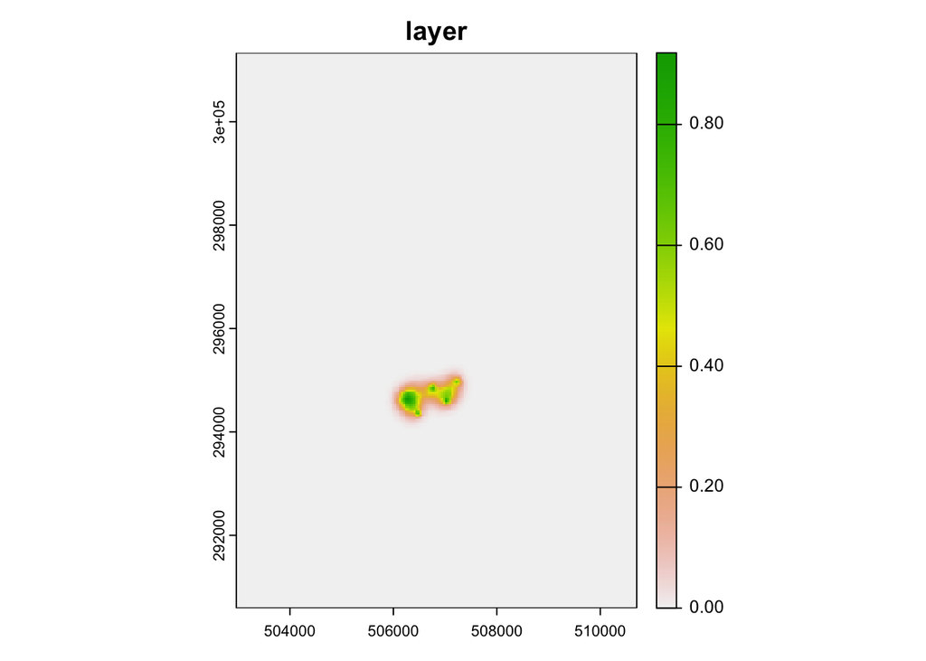

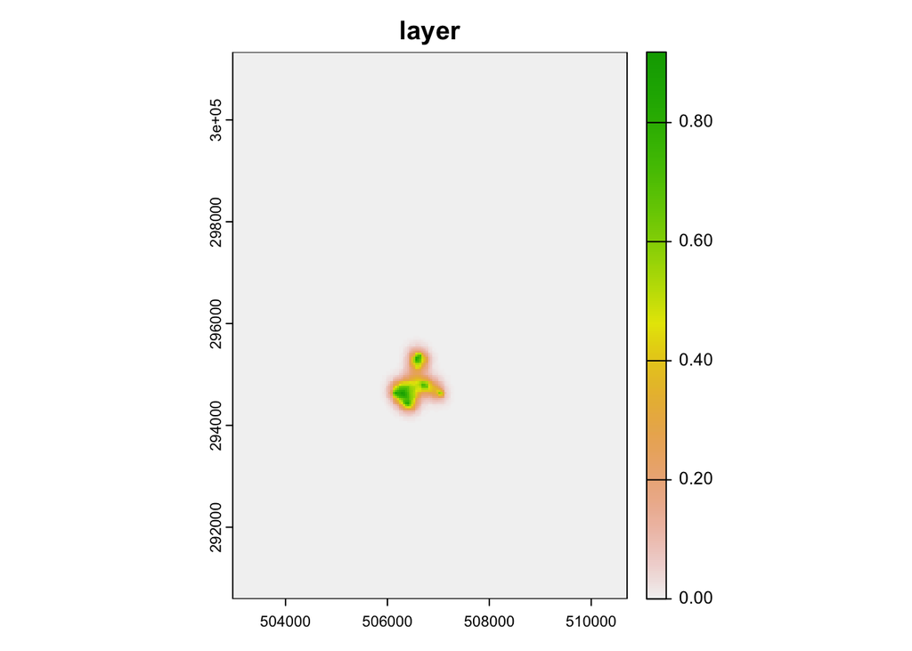

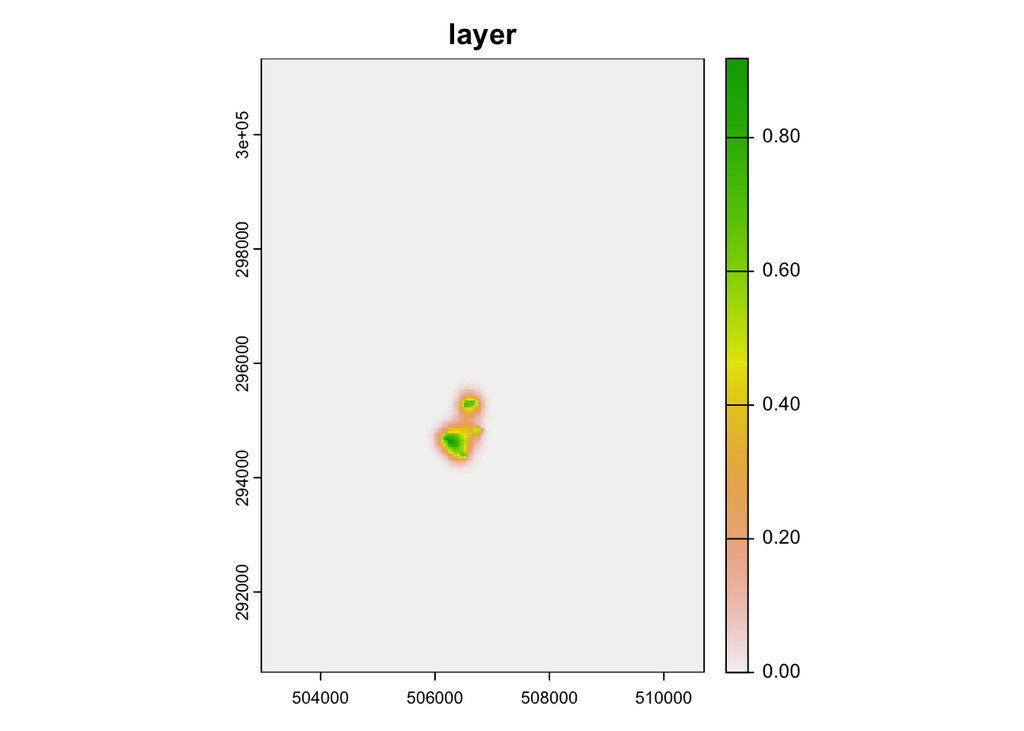

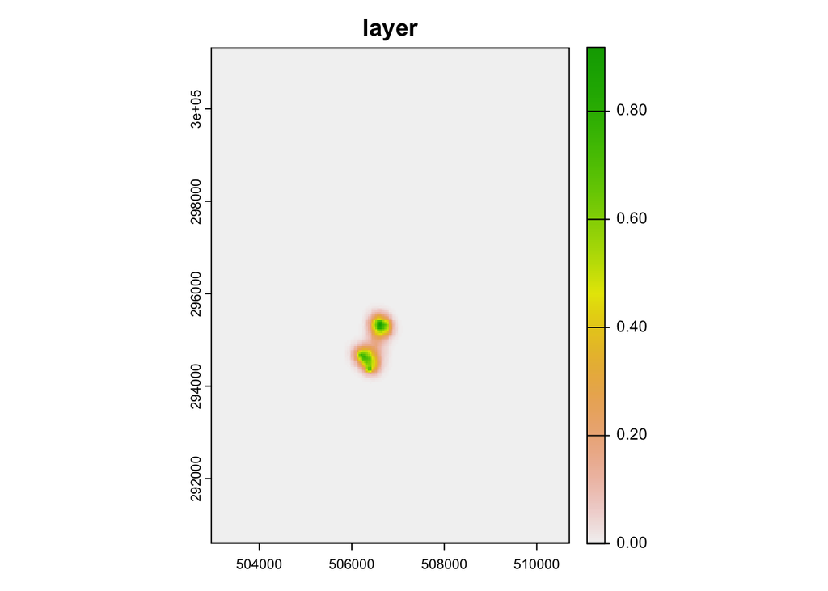

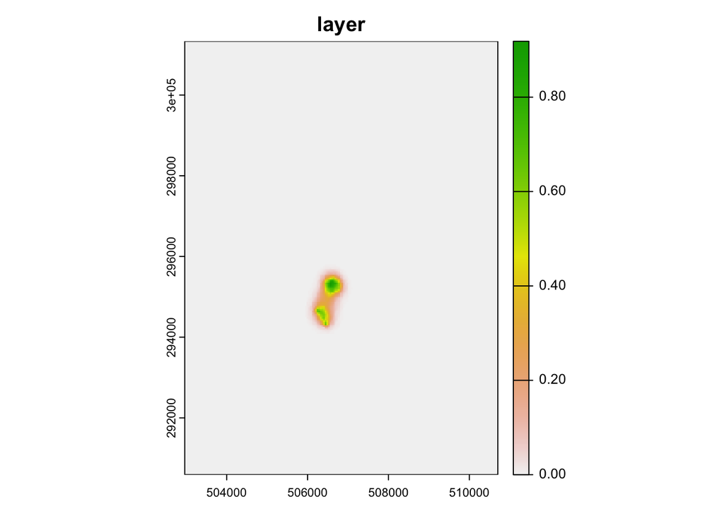

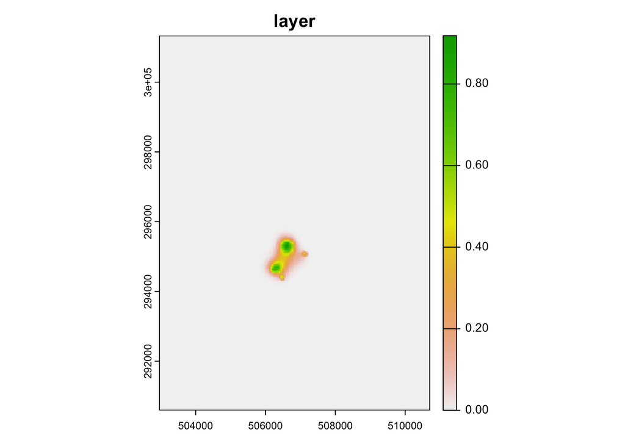

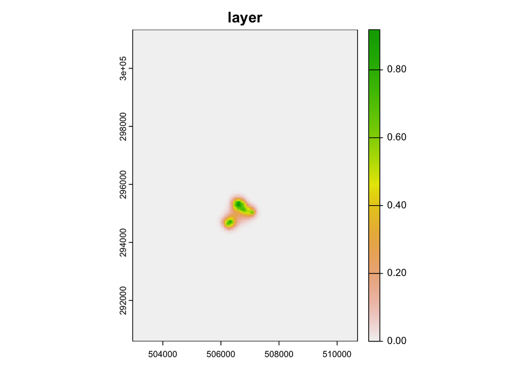

```r
od_roll_rast <- od_roll_tw$res
animate(od_roll_rast[[20:30]])
```

Exporting a raster stack of OD results then allows us to treat these like any other time-varying habitat covariate in an iSSF. We can see what that looks like in the next section.

## Random steps and extract covariates

Step-by-step tutorials for fitting and interpreting iSSFs are available from [Signer et al. 2019](https://doi.org/10.1002/ece3.4823) and [Fieberg et al. 2021](https://doi.org/10.1111/1365-2656.13441). **We strongly recommend interested users start with these resources.**

Before fitting an iSSF, we need to draw random steps for each observed step and then extract habitat covariates for observed and random steps. As outlined in the above resources, the *amt* package has functions for managing each of these steps.

We’ll demonstrate this process with movement data from one individual, and we’ll focus on the same three-month window we used for our OD roll demo:

```r
ssf.dat <- get(load("../Project_data/ssf_demo_movement_data.Rdata"))
ssf.dat <- ssf.dat[ssf.dat$date>="2017-03-01" & ssf.dat$date<"2017-06-01",]
head(ssf.dat)
```

```
##         id        x        y                date
## 37299 5050 507125.6 294615.2 2017-03-01 03:00:55
## 37300 5050 506785.9 294261.5 2017-03-01 07:02:01
## 37301 5050 506694.0 293581.5 2017-03-01 11:00:41
## 37302 5050 506507.0 294102.7 2017-03-01 15:00:52
## 37303 5050 507243.5 294533.8 2017-03-01 19:00:40
## 37304 5050 506753.9 294240.4 2017-03-01 23:00:38
```

First, we need to make this into a “track” object. While we’re only evaluating one individual, when evaluating many individuals, it’s very useful to store data in a nested tibble, so I’ll demonstrate that as well. We also need to add some metadata, so we’ll load that data and merge it into the tibble for this focal individual.

```r
## add a season for nested tibble demonstration purposes
ssf.dat$season <- "demo"
dt1 <- ssf.dat %>% make_track(.x = x, .y = y, .t = date, id = id, season = season,  crs = 3071)

## make into a nested tibble to make movement data easier to manage
dt2 <- dt1 %>% nest(data = c(-"id", -"season"))

## load and merge metadata
meta <- get(load("../Project_data/metadata_assembled_051022.Rdata"))
dt2 <- left_join(dt2, meta[,c("lowtag", "sex")], by = c("id" = "lowtag"))


## view data
dt2
```

```
## # A tibble: 1 × 4
##   id    season data                 sex
##   <chr> <chr>  <list>               <chr>
## 1 5050  demo   <trck_xyt [543 × 3]> Male
```

```r
head(dt2$data[[1]])
```

```
## # A tibble: 6 × 3
##        x_      y_ t_
## *   <dbl>   <dbl> <dttm>
## 1 507126. 294615. 2017-03-01 03:00:55.000000
## 2 506786. 294261. 2017-03-01 07:02:01.000000
## 3 506694. 293582. 2017-03-01 11:00:41.000000
## 4 506507. 294103. 2017-03-01 15:00:52.000000
## 5 507244. 294534. 2017-03-01 19:00:40.000000
## 6 506754. 294240. 2017-03-01 23:00:38.000000
```

Our “dt2” nested tibble is kind of like a data frame of data frames, and makes it really easy to keep large collections of different data and tables organized.

Next, we need to make sure our movement data is at regular intervals. Sometimes GPS collars will be on different schedules, depending on the season, but this can affect results in iSSFs. *amt* has important functions for reviewing the sampling rate of movement data and resampling that data to make sure the sampling rate is consistent. The most common fix rate in our study was one location every 4 hours, so we’ll use that as our target sampling rate.

A couple notes: I’ll make some plots below for reviewing fix rates (the number of hours between fixes). These are not very interesting plots when reviewing one individual, but are really useful when working with data for many individuals. I therefore include them as a reference for scaling this workflow up. In addition, our demo individual already has regular relocations, but I’m including the resampling steps for demo purposes.

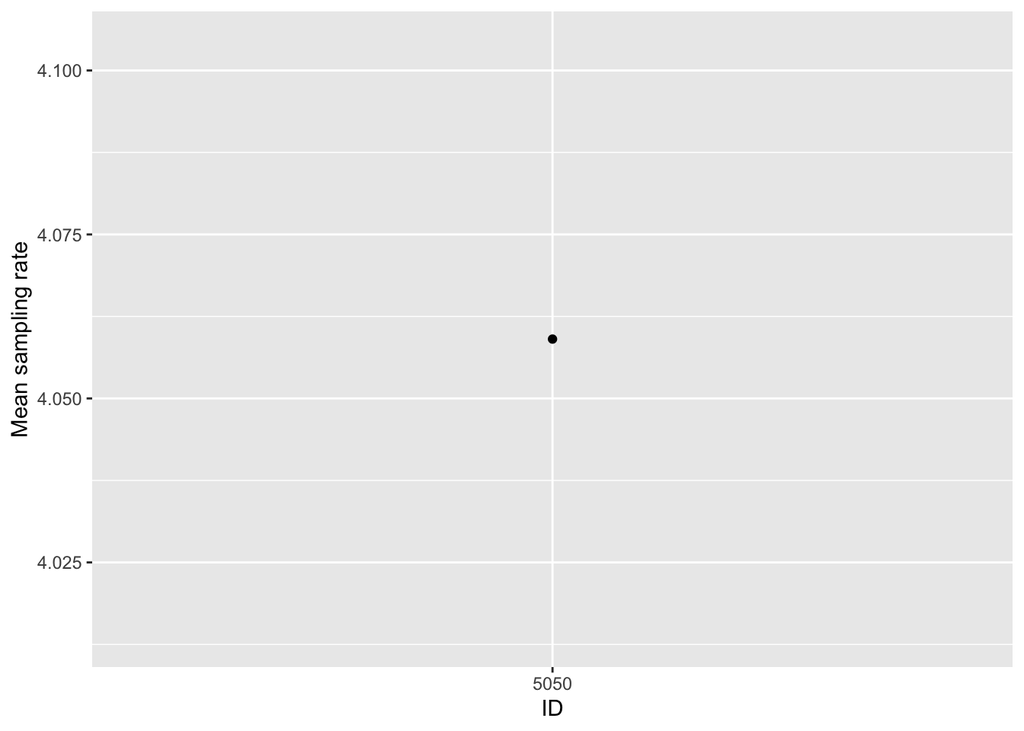

```r
### distribution of sampling rate intervals ###
review <- dt2 %>% mutate(sr = lapply(data, summarize_sampling_rate, time_unit = "hour")) %>%
  amt::select(id, season, sr) %>% unnest(cols = sr)
## plot mean hours between fixes by individual
ggplot(review, aes(x = as.factor(id), y  = mean)) + xlab("ID") + ylab("Mean sampling rate") + geom_point()
```

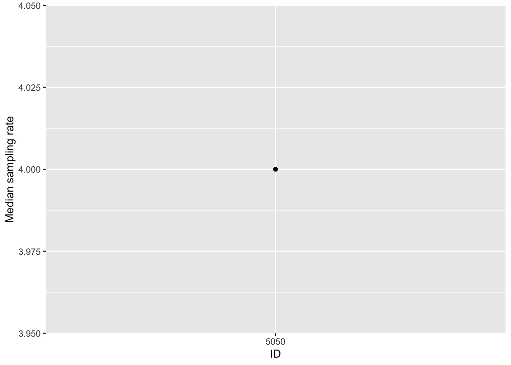

```r
## plot median hours between fixes by individual
ggplot(review, aes(x = as.factor(id), y  = median)) + xlab("ID") + ylab("Median sampling rate") + geom_point()
```

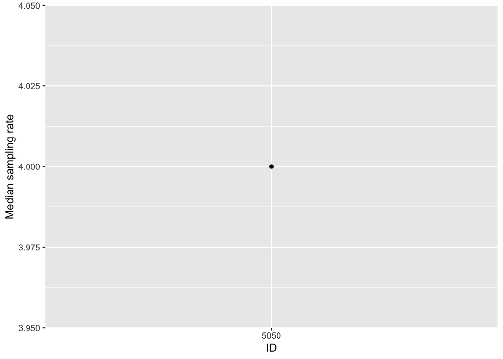

```r
### resample and filter locations to common fix rate ###
dt3 <- dt2 %>%
  mutate(resamp = lapply(data, function(x){
    x %>% amt::track_resample(rate = hours(4), tolerance = minutes(20)) %>%
      amt::filter_min_n_burst(min_n = 3)}))

# double check that the resampling worked as expected
review2 <- dt3 %>% mutate(sr = lapply(resamp, summarize_sampling_rate, time_unit = "hour")) %>%
  amt::select(id, season, sr) %>% unnest(cols = sr)
# all trajectories should have a median fix rate of ~4 hours
ggplot(review2, aes(x = as.factor(id), y  = median)) + xlab("ID") + ylab("Median sampling rate") + geom_point()
```

We now have a regularized movement data set. However, we can occasionally see relocations that result in a step length of zero. iSSFs in *amt* cannot accommodate a step length of zero, and these are also likely erroneous - GPS collars really aren’t accurate enough to get a step length of precisely zero. We therefore want to check for and remove any consecutive duplication locations (i.e., step lengths of zero) before we proceed. I do this with a few custom functions that count, identify, and remove step lengths of zero. Note: our demo individual does not have any of these zero step lengths (it’s really not a common problem), but I include it here for demonstration purposes because it is really annoying on the rare instances when it does occur.

```r
## function for counting the number of zero step lengths
nostep_num <- function(x){
  xs1 <- x$x_[1:(nrow(x)-1)]
  xs2 <- x$x_[2:nrow(x)]
  xsd <- xs2 - xs1
  xs0 <- which(xsd==0)

  ys1 <- x$y_[1:(nrow(x)-1)]
  ys2 <- x$y_[2:nrow(x)]
  ysd <- ys2 - ys1
  ys0 <- which(ysd==0)

  if(length(xs0)>0 & length(ys0)>0){
    out <- length(as.numeric(xs0[which(xs0==ys0)]+1)) # want the second occasion with the identical consecutive location
  }else{
    out <- 0
  }
  return(out)
}

## function that outputs the index of any zero step lengths
nostep_id <- function(x){
  xs1 <- x$x_[1:(nrow(x)-1)]
  xs2 <- x$x_[2:nrow(x)]
  xsd <- xs2 - xs1
  xs0 <- which(xsd==0)

  ys1 <- x$y_[1:(nrow(x)-1)]
  ys2 <- x$y_[2:nrow(x)]
  ysd <- ys2 - ys1
  ys0 <- which(ysd==0)

  if(length(xs0)>0 & length(ys0)>0){
    out <- as.numeric(xs0[which(xs0==ys0)]+1) # want the second occasion with the identical consecutive location
  }else{
    out <- NA
  }
  return(out)
}

## function that removes any step lengths of zero
remove_nostep <- function(x){
  xs1 <- x$x_[1:(nrow(x)-1)]
  xs2 <- x$x_[2:nrow(x)]
  xsd <- xs2 - xs1
  xs0 <- which(xsd==0)

  ys1 <- x$y_[1:(nrow(x)-1)]
  ys2 <- x$y_[2:nrow(x)]
  ysd <- ys2 - ys1
  ys0 <- which(ysd==0)

  if(length(xs0)>0 & length(ys0)>0){
    rem <- as.numeric(xs0[which(xs0==ys0)]+1) # want the second occasion with the identical consecutive location
    out <- x[-rem,]
  }else{
    out <- x
  }

  return(out)
}

# max number of duplicated steps in a seasonal trajectory (this is a fairly rare problem) - none, in this instance
max(unlist(lapply(dt3$resamp, nostep_num)))
```

```
## [1] 0
```

```r
# datasets that have a duplicate consecutive location (step length = 0) - none, in this instance
which(is.na(unlist(lapply(dt3$resamp, nostep_id)))==F)
```

```
## integer(0)
```

```r
# index of the second location (the repeated one that should be removed) - none, in this instance
inds <- unlist(lapply(dt3$resamp, nostep_id))


# remove the repeated location
dt4 <- dt3 %>%
  mutate(norep = lapply(resamp, function(x){
    x %>% remove_nostep
  }))
max(unlist(lapply(dt4$norep, nostep_num))) # check that it worked (this will stay at zero in our demo because there weren't any zero step lengths in the first place)
```

```
## [1] 0
```

We are now ready to convert our “clean” movement data from points to steps.

```r
#### convert from points to steps ####
ds1 <- dt4 %>%
  mutate(stp = lapply(norep, function(x){
    # re-run filtering because we may have removed some locations in the zero step length processing
    x %>% amt::filter_min_n_burst(min_n = 3) %>%
      amt::steps_by_burst()
  }))

## view data
ds1
```

```
## # A tibble: 1 × 7
##   id    season data                 sex   resamp     norep      stp
##   <chr> <chr>  <list>               <chr> <list>     <list>     <list>
## 1 5050  demo   <trck_xyt [543 × 3]> Male  <trck_xyt> <trck_xyt> <brstd_s_>
```

```r
head(ds1$stp[[1]])
```

```
## # A tibble: 6 × 11
##   burst_     x1_     x2_     y1_     y2_   sl_ direction_p    ta_
## *  <dbl>   <dbl>   <dbl>   <dbl>   <dbl> <dbl>       <dbl>  <dbl>
## 1      1 507126. 506786. 294615. 294261. 490.       -2.34  NA
## 2      1 506786. 506694. 294261. 293582. 686.       -1.71   0.631
## 3      1 506694. 506507. 293582. 294103. 554.        1.92  -2.66
## 4      1 506507. 507244. 294103. 294534. 853.        0.530 -1.39
## 5      1 507244. 506754. 294534. 294240. 571.       -2.60  -3.13
## 6      1 506754. 506745. 294240. 294254.  16.5       2.15  -1.53
## # ℹ 3 more variables: t1_ <dttm>, t2_ <dttm>, dt_ <drtn>
```

Now that our data is in step format, we can do the key steps of drawing random steps and extracting our covariates. I’m going to demonstrate this with two “static” habitat covariates, elevation and distance to nearest forest edge, and one time-varying habitat covariate. For the time-varying habitat covariate, we’ll use the rolling OD I demonstrated above, as that individual has some habitat overlap with our current focal individual. Again, *amt* has great functions for streamlining this whole process.

```r
## extract step data from our nested tibble (can readily scale this up by looping through each "stp" table in ds1)
step.dat <- ds1$stp[[1]]

## draw 10 random steps
set.seed(96513) # set seed for reproducibility paranoia
step.dat <- step.dat %>%
    random_steps(n_control = 10)


### load static landscape variables (elevation and distance to forest edge)
## elevation
ele <- rast(get(load("../Project_data/elevation.Rdata"))) # originally made as a "raster" object
names(ele) <- "ele"

## distance to forest edge
fe <- rast(get(load("../Project_data/distance_to_forest_edge_raster.Rdata")))

### extract static landscape variables
step.dat_statcov <- step.dat %>%
  extract_covariates(ele, where = "end") %>%
  extract_covariates(fe, where = "end")


### load time-varying covariate (OD roll)
od_roll_demo <- rast("../Project_data/od_roll_demo_roll.tif")
# check and correct time zone if needed (it may be converted to UTC times in the saving/loading process; definitely check with your own data)
attr(time(od_roll_demo), "tzone") <- "UTC"
attr(time(od_roll_demo), "tzone") <- "America/Chicago"


## extract as a time-varying covariate
step.dat_allcov <- step.dat_statcov %>%
  extract_covariates_var_time(od_roll_demo, max_time = hours(2), when = "any",
                              where = "end",
                              name_covar = "neighbor1")

print(head(step.dat_allcov), width = Inf)
```

```
## # A tibble: 6 × 15
##   burst_     x1_     x2_     y1_     y2_   sl_    ta_ t1_
## *  <dbl>   <dbl>   <dbl>   <dbl>   <dbl> <dbl>  <dbl> <dttm>
## 1      1 506786. 506694. 294261. 293582. 686.   0.631 2017-03-01 07:02:01.000000
## 2      1 506786. 506810. 294261. 294338.  80.3 -2.68  2017-03-01 07:02:01.000000
## 3      1 506786. 506780. 294261. 294109. 153.   0.724 2017-03-01 07:02:01.000000
## 4      1 506786. 506751. 294261. 294274.  37.2 -1.16  2017-03-01 07:02:01.000000
## 5      1 506786. 506222. 294261. 294163. 572.  -0.632 2017-03-01 07:02:01.000000
## 6      1 506786. 506960. 294261. 294228. 177.   2.15  2017-03-01 07:02:01.000000
##   t2_                        dt_            case_ step_id_   ele fe.dist
## * <dttm>                     <drtn>         <lgl>    <dbl> <dbl>   <dbl>
## 1 2017-03-01 11:00:41.000000 3.977778 hours TRUE         3  313.    216.
## 2 2017-03-01 11:00:41.000000 3.977778 hours FALSE        3  310.      0
## 3 2017-03-01 11:00:41.000000 3.977778 hours FALSE        3  296.     30
## 4 2017-03-01 11:00:41.000000 3.977778 hours FALSE        3  300.     60
## 5 2017-03-01 11:00:41.000000 3.977778 hours FALSE        3  309.     90
## 6 2017-03-01 11:00:41.000000 3.977778 hours FALSE        3  282.      0
##   neighbor1
## *     <dbl>
## 1        NA
## 2        NA
## 3        NA
## 4        NA
## 5        NA
## 6        NA
```

```r
print(tail(step.dat_allcov), width = Inf)
```

```
## # A tibble: 6 × 15
##   burst_     x1_     x2_     y1_     y2_   sl_    ta_ t1_
## *  <dbl>   <dbl>   <dbl>   <dbl>   <dbl> <dbl>  <dbl> <dttm>
## 1     10 506338. 507115. 293014. 292954. 779.   1.53  2017-05-31 16:01:24.000000
## 2     10 506338. 506358. 293014. 293022.  21.3  1.96  2017-05-31 16:01:24.000000
## 3     10 506338. 506458. 293014. 292599. 432.   0.320 2017-05-31 16:01:24.000000
## 4     10 506338. 506368. 293014. 293369. 355.   3.10  2017-05-31 16:01:24.000000
## 5     10 506338. 506909. 293014. 293183. 595.   1.90  2017-05-31 16:01:24.000000
## 6     10 506338. 506147. 293014. 293023. 191.  -1.58  2017-05-31 16:01:24.000000
##   t2_                        dt_         case_ step_id_   ele fe.dist neighbor1
## * <dttm>                     <drtn>      <lgl>    <dbl> <dbl>   <dbl>     <dbl>
## 1 2017-05-31 20:01:06.000000 3.995 hours FALSE      532  233.    30           0
## 2 2017-05-31 20:01:06.000000 3.995 hours FALSE      532  307.   170.          0
## 3 2017-05-31 20:01:06.000000 3.995 hours FALSE      532  326.    30           0
## 4 2017-05-31 20:01:06.000000 3.995 hours FALSE      532  307.   210           0
## 5 2017-05-31 20:01:06.000000 3.995 hours FALSE      532  254.    67.1         0
## 6 2017-05-31 20:01:06.000000 3.995 hours FALSE      532  294.   247.          0
```

We see that we have some missing observations for overlap with the OD roll neighbor. This is because our OD roll doesn’t start until 3/2/2017, so no rasters in our OD roll raster stack are within the 2 hour “max time” we’ve specified in the extract_covariates_var_time() function.

These are just a few examples of covariate extraction, but this can be scaled up/modified for additional habitat covariates, including ones that vary in time.

Because we’re going to fit iSSFs, we’ll also want to include some movement variables; in this case, log-step length and cos(turning angle). We can do that here.

```r
step.dat_allcov$log_sl_ <- log(step.dat_allcov$sl_)
step.dat_allcov$cos_ta_ <- cos(step.dat_allcov$ta_)
```

Once we’ve extracted all our habitat and movement covariates, we can move on to the actual iSSF fitting.

## Fitting an iSSF

For simplicity, I’ll just demo fitting a very simple iSSF. Guidance - including code - is readily available through the Signer et al. and Fieberg et al. papers linked above. Interested users should start with these resources to ensure they understand the fundamentals before building their own models.

As in the accompanying manuscript, we’ll start by scaling and centering some of our continuous covariates. In the manuscript, we scaled and centered based on population-level values for our covariates; since we’re just working with one individual here, we’ll scale and center based on individual-level values.

```r
## Scale and center
step.dat_allcov$log_sl_.sc <- scale(step.dat_allcov$log_sl_)
step.dat_allcov$cos_ta_.sc <- scale(step.dat_allcov$cos_ta_)
step.dat_allcov$ele.sc <- scale(step.dat_allcov$ele)
step.dat_allcov$fe.dist.sc <- scale(step.dat_allcov$fe.dist)
```

For the very simple iSSF we’re fitting, we can just use the fit_issf() function that’s part of the *amt* package. However, in our manuscript, we fit several variations of iSSFs to each movement trajectory. In situations like this, writing a function to select from several different model formulations can be helpful. I’ll demo that here.

```r
## Fit mods function
fit.mods <- function(try.neighs = FALSE,
                     neighs = NULL, ## a list of neighbor "names"; i.e., the column names for neighbors
                     ssf.data = ste.dat_allcov,
                     snow = FALSE){

  ## what to include in the model formula if a snow covariate is included
  if(snow){
    snow.ins <- "poly(snow_end, 3, raw = TRUE) + "
  }else{
    snow.ins <- ""
  }

  ## what to include in the model formula if neighbors are being included (accounts for not knowing how many neighbors will be included)
  if(try.neighs){
    neighs <- paste(neighs, sep = " ", collapse = " ")
    neighs <- gsub(" ", " + ", neighs)
    neighs <- paste(neighs, " + ", collapse = " ")
  }else{
    neighs <- ""
  }

  ## construct the model formula
  model.formula <- as.formula(paste(
    "case_ ~
    log_sl_.sc + cos_ta_.sc +
    fe.dist.sc +
    poly(ele.sc, 2, raw = TRUE) + ",
    snow.ins, neighs, "strata(step_id_)",
    collapse = " "
  ))



  ## attempt to fit the model; return an NA result if model fails
  mod <- tryCatch({
    ssf.data %>% fit_issf(model.formula, model = T)
  }, warning=function(w) {

    ## do something about the warning, maybe return 'NA'
    # message("handling warning no mod: ", conditionMessage(w))
    NA
  }, error = function(err){
    # message("handling error no mod: ", conditionMessage(err))
    NA
  })


  ## output the results
  mod.out <- list(mod, ssf.data)
  names(mod.out) <- c("model", "ssf.data")
  return(mod.out)

}
```

Now that we have our model fitting function, we can try to fit a model. We’ll fit a version including “neighbor1” as a time-varying habitat covariate to test for selection or avoidance of this individual.

```r
## extract the column names associated with our "neighbor" covariates
neighbors <- colnames(step.dat_allcov)[grepl("neighbor", colnames(step.dat_allcov))]

## fit a model; we're not including snow cover, so we'll set that to FALSE
demo.issf <- fit.mods(try.neighs = T, neighs = neighbors, ssf.data = step.dat_allcov, snow = FALSE)

## extract and review results
summary(demo.issf$model)
```

```
## Call:
## coxph(formula = Surv(rep(1, 5742L), case_) ~ log_sl_.sc + cos_ta_.sc +
##     fe.dist.sc + poly(ele.sc, 2, raw = TRUE) + neighbor1 + strata(step_id_),
##     data = data, model = ..1, method = "exact")
##
##   n= 5654, number of events= 514
##    (88 observations deleted due to missingness)
##
##                                  coef exp(coef) se(coef)      z Pr(>|z|)
## log_sl_.sc                    0.08533   1.08907  0.04842  1.762   0.0780 .
## cos_ta_.sc                   -0.01433   0.98577  0.04674 -0.307   0.7591
## fe.dist.sc                    0.33049   1.39165  0.05506  6.002 1.95e-09 ***
## poly(ele.sc, 2, raw = TRUE)1  0.07408   1.07690  0.06294  1.177   0.2392
## poly(ele.sc, 2, raw = TRUE)2  0.02312   1.02339  0.05946  0.389   0.6974
## neighbor1                     0.72116   2.05682  0.36027  2.002   0.0453 *
## ---
## Signif. codes:  0 '***' 0.001 '**' 0.01 '*' 0.05 '.' 0.1 ' ' 1
##
##                              exp(coef) exp(-coef) lower .95 upper .95
## log_sl_.sc                      1.0891     0.9182    0.9905     1.197
## cos_ta_.sc                      0.9858     1.0144    0.8995     1.080
## fe.dist.sc                      1.3917     0.7186    1.2493     1.550
## poly(ele.sc, 2, raw = TRUE)1    1.0769     0.9286    0.9519     1.218
## poly(ele.sc, 2, raw = TRUE)2    1.0234     0.9771    0.9108     1.150
## neighbor1                       2.0568     0.4862    1.0152     4.167
##
## Concordance= 0.583  (se = 0.015 )
## Likelihood ratio test= 47.3  on 6 df,   p=2e-08
## Wald test            = 48.84  on 6 df,   p=8e-09
## Score (logrank) test = 49.91  on 6 df,   p=5e-09
```

And now we have a fitted model! This is, of course, a fairly simple model, but shows how we can begin to scale up, efficiently try different model types, and fit models for many different trajectories.

## Log-RSS calculation

When evaluating the results of iSSFs, we can’t just look at the covariate estimates: we need to consider log-relative selection strength (log-RSS). For thorough explanation of log-RSS - what these values are and how to calculate them - please read [Avgar et al. 2017](https://doi.org/10.1002/ece3.3122). **This is really required reading for interpreting habitat- and step-selection results.**

The *amt* package comes with a built in function for calculating log-RSS values based on fitted models. However, we must provide this function with data frames representing a single hypothetical reference location (x2), and one or more alternative locations (x1).

Let’s look at the log-RSS for varying levels of (scaled and centered) forest edge distance. We can start by setting a reference location (x2). We need to include all the variables (with appropriate names) from our fitted model; because most of our continuous covariates were scaled and centered, when we set them to zero, we’re setting them to their average values. We didn’t scale and center the neighbor covariate, so this is just representing a location where the neighbor wasn’t present.

```r
x2 <- data.frame(
  log_sl_.sc = 0,
  cos_ta_.sc = 0,
  fe.dist.sc = 0,
  ele.sc = 0,
  neighbor1 = 0
)
```

Now we can create our x1 data frame, representing a selection of “alternative” locations. We just want to see the effect of forest edge distance, so that’s the only value we’ll alter.

```r
x1 <- data.frame(
  log_sl_.sc = 0,
  cos_ta_.sc = 0,
  fe.dist.sc = seq(-1, 5, by = 0.5), # range is based on the range of observed values
  ele.sc = 0,
  neighbor1 = 0
)
```

We can now feed these into the log_rss() function and plot our results.

```r
forest.lrss <- log_rss(demo.issf$model, x1 = x1, x2 = x2)
forest.lrss <- forest.lrss$df
head(forest.lrss)
```

```
##   log_sl_.sc_x1 cos_ta_.sc_x1 fe.dist.sc_x1 ele.sc_x1 neighbor1_x1    log_rss
## 1             0             0          -1.0         0            0 -0.3304936
## 2             0             0          -0.5         0            0 -0.1652468
## 3             0             0           0.0         0            0  0.0000000
## 4             0             0           0.5         0            0  0.1652468
## 5             0             0           1.0         0            0  0.3304936
## 6             0             0           1.5         0            0  0.4957404
```

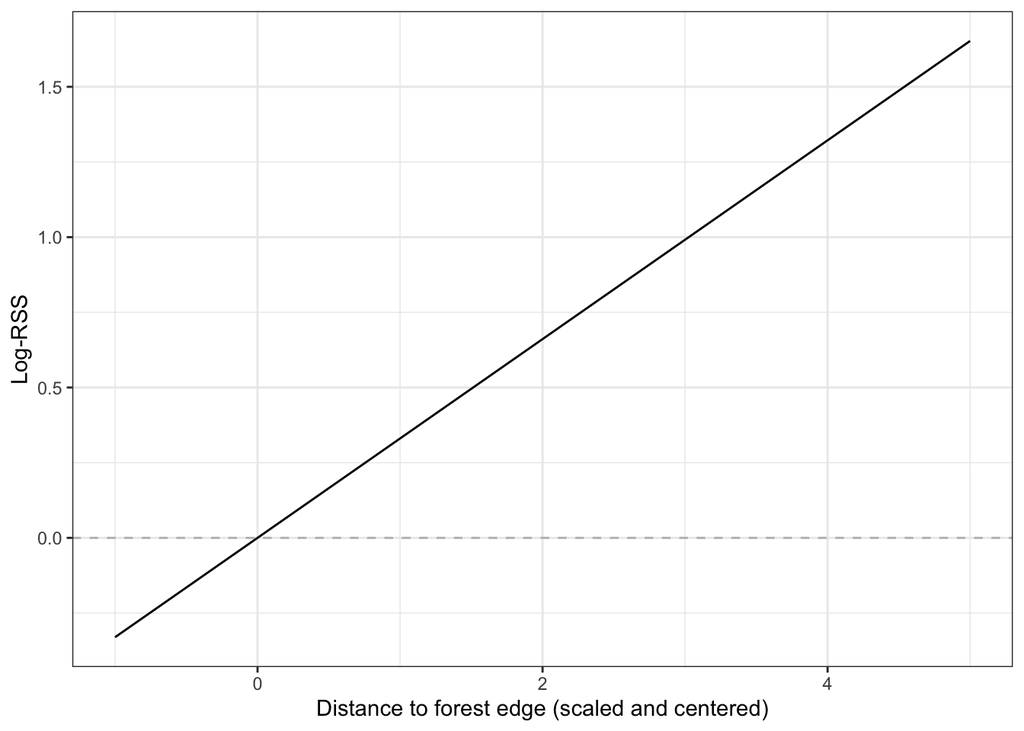

```r
ggplot(forest.lrss, aes(x = fe.dist.sc_x1, y = log_rss)) +
  geom_hline(yintercept = 0, colour = "grey", linetype = "dashed") +
  geom_path() +
  xlab("Distance to forest edge (scaled and centered)") + ylab("Log-RSS") +
  theme_bw()
```

Note: for simple additive effects like this, the slope of the line in the above figure corresponds to the covariate estimate from the fitted iSSF (in this case, 0.33).

Things are more complicated for other kinds of models terms. As an example, we’ll look at elevation, which was modeled as a second order polynomial. This is where you **definitely** should read the Avgar et al. paper linked above, as this structure makes log-RSS sensitive to habitat values.

We’ll leave x2 the same, but now we’ll vary elevation for our alternative locations (x1).

```r
x1 <- data.frame(
  log_sl_.sc = 0,
  cos_ta_.sc = 0,
  fe.dist.sc = 0,
  ele.sc = seq(-2, 2, 0.2), # range is based on the range of observed values
  neighbor1 = 0
)

ele.lrss <- log_rss(demo.issf$model, x1 = x1, x2 = x2)
ele.lrss <- ele.lrss$df
head(ele.lrss)
```

```
##   log_sl_.sc_x1 cos_ta_.sc_x1 fe.dist.sc_x1 ele.sc_x1 neighbor1_x1     log_rss
## 1             0             0             0      -2.0            0 -0.05569089
## 2             0             0             0      -1.8            0 -0.05844444
## 3             0             0             0      -1.6            0 -0.05934852
## 4             0             0             0      -1.4            0 -0.05840312
## 5             0             0             0      -1.2            0 -0.05560824
## 6             0             0             0      -1.0            0 -0.05096389
```

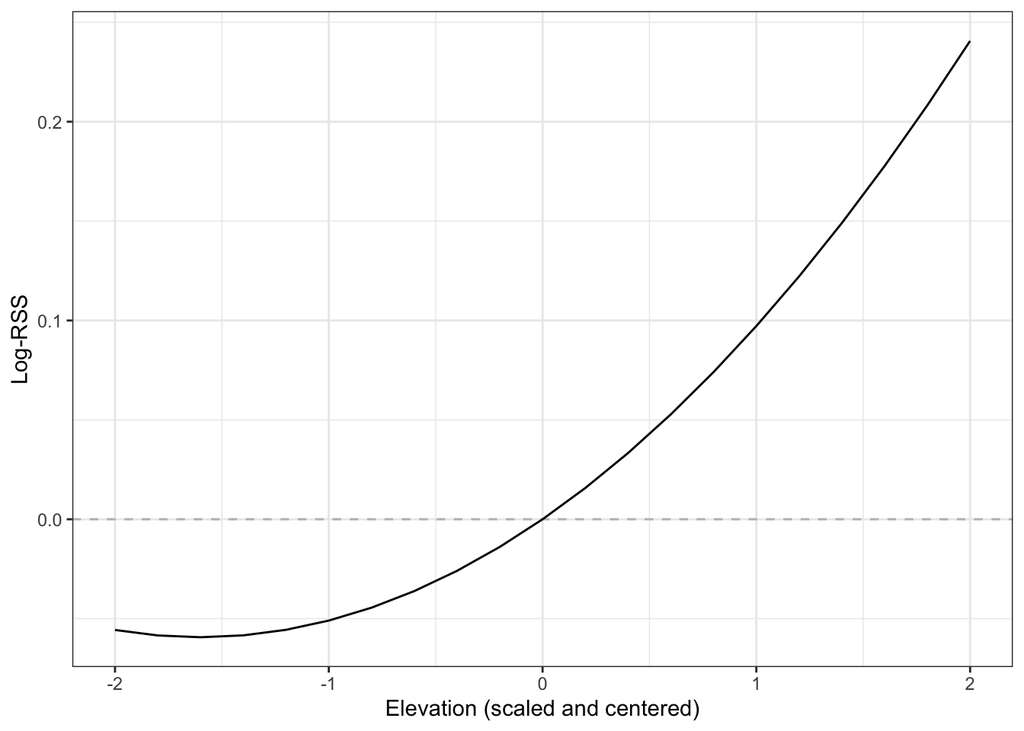

```r
ggplot(ele.lrss, aes(x = ele.sc_x1, y = log_rss)) +
  geom_hline(yintercept = 0, colour = "grey", linetype = "dashed") +
  geom_path() +
  xlab("Elevation (scaled and centered)") + ylab("Log-RSS") +
  theme_bw()
```

After calculating our log-RSS values, we can make these the response variables in meta-analyses to understand how factors like sex and season affect habitat selection.

## Meta-analysis approach

A population-level approach to fitting iSSFs (e.g., [Muff et al. 2019](https://doi.org/10.1111/1365-2656.13087)) is generally preferable over a meta-analysis of individual-level models. However, when including neighbors, all individuals have a different suite of neighbors, so a population-level approach doesn’t work. Instead, we’ll use the log-RSS values for our different covariates from above as response variables in “meta-analysis” models.

We might, for example, test how selection for proximity to forest edges varies with factors like season and sex. These models are no different from your standard regression analyses; if you have repeated observations for individuals, you can fit mixed effect models to account for that kind of correlated data. These regression methods are standard in R, so I won’t do a full demo here. However, let’s say we have a data frame called “log.rss.data”, with columns for (1) log-RSS for elevation, *log.RSS.elevation*, (2) season, (3) sex, and (4) indiviaul ID, *ID*. Fitting a linear mixed model could look something like this:

```r
meta.model <- lmer(log.RSS.elevation ~ season * sex + (1|ID), data = log.rss.data)
```

In the above example, we’d be fitting a linear mixed effects model with log-RSS values for elevation as the response variable, and an interaction between season and sex as fixed effects. The model also includes random intercepts for individual.

## Closing

And that’s it! I’ll just close with some session info. All of the packages loaded were not necessarily used to create this report, but they were necessary for scaling up this work to many individuals or performing the full meta-analysis, so I’ve included them here for completeness.

[session information not shown]